# Synthetic Control Carbon Tax

Ben Gilbert

12/3/2023

## Welcome

This is a demonstration of the results in

*Andersson, J. J. (2019). Carbon taxes and CO 2 emissions: Sweden as a case study. American Economic Journal: Economic Policy, 11(4), 1-30.*

Using synthetic control methods in R to show the impact of the carbon tax in Sweden’s transportation sector on carbon dioxide emissions.

We also compare the traditional Synth results to Hollingsworth 2021 “Synthetic Control with LASSO” or SCUL package.

### Packages needed

The first thing you need to do is install and load a few packages to make sure everything runs:

```r
install.packages("devtools")
install.packages("SCtools")
install.packages("Synth")
install.packages("scul")
```

### Load packages and main dataset

```r
library(Synth)
library(tidyverse)
library(haven)
library(devtools)
if(!require(SCtools)) devtools::install_github("bcastanho/SCtools")
require(SCtools)
library(foreign)
require(scul)
require(cowplot)

setwd("C:/Users/gilbe/Dropbox/Econometrics/Petes Class/EB 590 Spring 2021/CarbonTaxSynthExample")

carbontax <- read_dta("carbontax_data.dta") %>%
   as.data.frame(.)
```

## Prepare data in format for Synth package

The Synth package requires the standard data set to be formatted in a specific way, with fields for predictors, time periods, etc.

```r
 dataprep.out <-
              dataprep(foo = carbontax,
                       predictors = c("GDP_per_capita" , "gas_cons_capita" , "vehicles_capita" ,
                                      "urban_pop") ,
                       predictors.op = "mean" ,
                       time.predictors.prior = 1980:1989 ,
                       special.predictors = list(
                         list("CO2_transport_capita" , 1989 , "mean"),
                         list("CO2_transport_capita" , 1980 , "mean"),
                         list("CO2_transport_capita" , 1970 , "mean")
                                                ),
                       dependent = "CO2_transport_capita",
                       unit.variable = "Countryno",
                       unit.names.variable = "country",
                       time.variable = "year",
                       treatment.identifier = 13,
                       controls.identifier = c(1:12, 14:15),
                       time.optimize.ssr = 1960:1989,
                       time.plot = 1960:2005
                       )
```

# Estimate the synthetic control weights

Estimate the weights and report optimal weights and covariate balance results in tables.

```r
 synth.out <- synth(data.prep.obj = dataprep.out,
                    method = "All")
```

```
##
## X1, X0, Z1, Z0 all come directly from dataprep object.
##
##
## ****************
##  searching for synthetic control unit
##
##
## ****************
## ****************
## ****************
##
## MSPE (LOSS V): 0.001222443
##
## solution.v:
##  0.2188493 0.009719276 0.07826532 0.2126716 0.1832151 0.2838626 0.01341685
##
## solution.w:
##  0.0007695733 0.1954709 5.61912e-05 0.3842992 0.0003365576 0.09042864 0.001226448 0.0003818197 0.1765464 0.0006891624 0.0003987502 0.0004105377 0.06109071 0.08789508
```

```r
###################################################
 synth.tables <- synth.tab(dataprep.res = dataprep.out,
                           synth.res = synth.out
                           )

###################################################
### Table 1: CO2 Emissions From Transport Predictor Means Before Tax Reform
###################################################
 synth.tables$tab.pred[1:7, ]
```

```
##                                     Treated Synthetic Sample Mean
## GDP_per_capita                    20121.479 20121.207   18706.663
## gas_cons_capita                     456.178   406.220     425.510
## vehicles_capita                     405.562   406.773     402.368
## urban_pop                            83.099    83.082      75.238
## special.CO2_transport_capita.1989     2.506     2.478       2.371
## special.CO2_transport_capita.1980     2.005     2.033       2.121
## special.CO2_transport_capita.1970     1.729     1.672       1.637
```

```r
###################################################
### Table 2: Country Weights in Synthetic Sweden
###################################################
 synth.tables$tab.w[1:14, ]
```

```
##    w.weights    unit.names unit.numbers
## 1      0.001     Australia            1
## 2      0.195       Belgium            2
## 3      0.000        Canada            3
## 4      0.384       Denmark            4
## 5      0.000        France            5
## 6      0.090        Greece            6
## 7      0.001       Iceland            7
## 8      0.000         Japan            8
## 9      0.177   New Zealand            9
## 10     0.001        Poland           10
## 11     0.000      Portugal           11
## 12     0.000         Spain           12
## 14     0.061   Switzerland           14
## 15     0.088 United States           15
```

## Show the main takeaway figures

These are the main results before evaluating and testing.

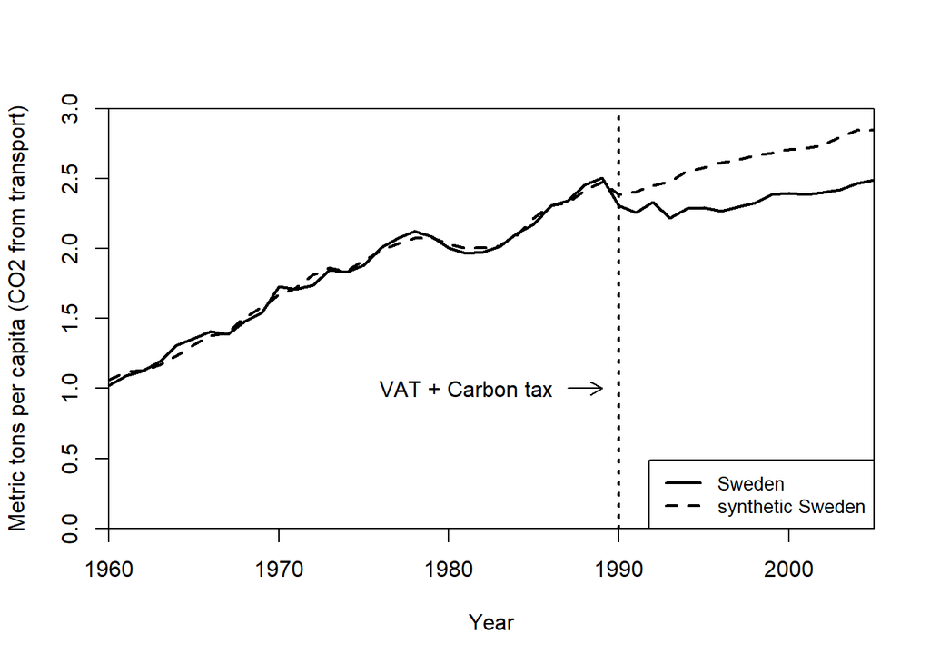

```r
###################################################
### Figure 4: Path Plot of per capita CO2 Emissions from Transport
###################################################
  path.plot(synth.res = synth.out,
           dataprep.res = dataprep.out,
           Ylab = "Metric tons per capita (CO2 from transport)",
           Xlab = "Year",
           Ylim = c(0,3),
           Legend = c("Sweden","synthetic Sweden"),
           Legend.position = "bottomright"
           )
# Add line
abline(v=1990,lty="dotted",lwd=2)
arrows(1987,1.0,1989,1.0,col="black",length=.1)
Cex.set <- 1
text(1981,1.0,"VAT + Carbon tax",cex=Cex.set)
```

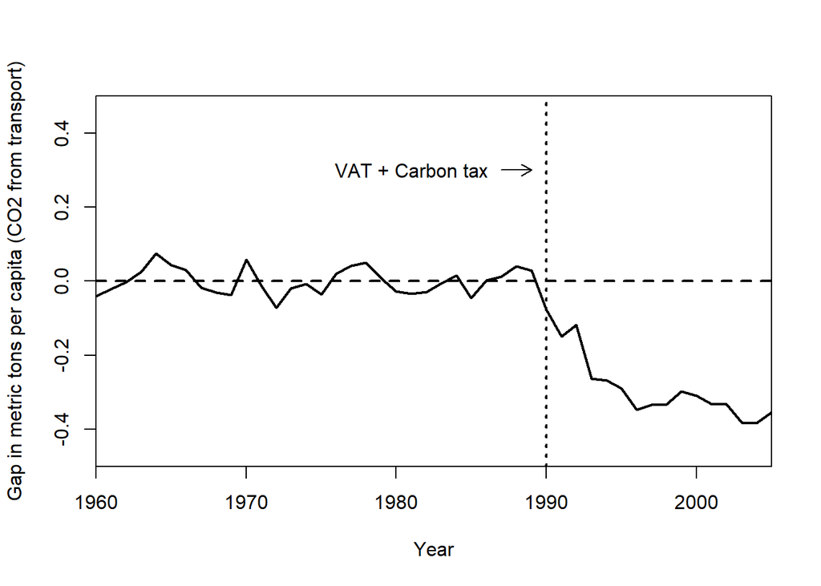

```r
###################################################
### Figure 5: Gap in per capita CO2 Emissions from Transport between Sweden and Synthetic Sweden
###################################################
 gaps.plot(synth.res = synth.out,
           dataprep.res = dataprep.out,
           Ylab = "Gap in metric tons per capita (CO2 from transport)",
           Xlab = "Year",
           Ylim = c(-0.5,0.5),
           Main = NA
           )

#Add line
abline(v=1990,lty="dotted",lwd=2)
arrows(1987,0.3,1989,0.3,col="black",length=.1)
Cex.set <- 1
text(1981,0.3,"VAT + Carbon tax",cex=Cex.set)
```

## Check placebo treatment years: 1980 and 1970

```r
###################################################
### Figure 6:  Placebo in-time tests 1980/1970
###################################################
#Placebo test in time for 1980
dataprep.out <-
              dataprep(foo = carbontax,
                       predictors = c("GDP_per_capita" , "gas_cons_capita" , "vehicles_capita" ,
                                      "urban_pop") ,
                       predictors.op = "mean" ,
                       time.predictors.prior = 1970:1979 ,
                       special.predictors = list(
                         list("CO2_transport_capita" , 1979 , "mean"),
                         list("CO2_transport_capita" , 1970 , "mean"),
                         list("CO2_transport_capita" , 1965 , "mean")
                                                ),
                       dependent = "CO2_transport_capita",
                       unit.variable = "Countryno",
                       unit.names.variable = "country",
                       time.variable = "year",
                       treatment.identifier = 13,
                       controls.identifier = c(1:12,14:15),
                       time.optimize.ssr = 1960:1979,
                       time.plot = 1960:1990
                       )

synth.out <- synth(
                   data.prep.obj = dataprep.out,
                   method = "BFGS"
                   )
```

```
##
## X1, X0, Z1, Z0 all come directly from dataprep object.
##
##
## ****************
##  searching for synthetic control unit
##
##
## ****************
## ****************
## ****************
##
## MSPE (LOSS V): 0.001500508
##
## solution.v:
##  0.1562492 0.5783013 0.01223948 0.02842847 0.1830067 0.04177432 4.254e-07
##
## solution.w:
##  0.04915065 0.1607624 0.00286956 0.5193108 0.001615248 0.003992957 0.0009714243 0.01298892 0.1447179 0.03245229 0.004764193 0.007168443 0.001224774 0.05801042
```

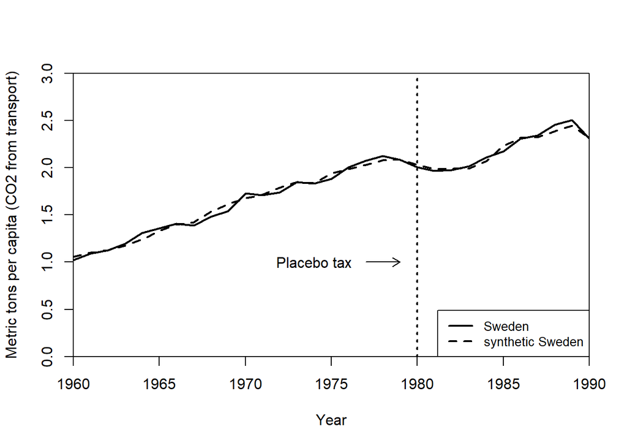

```r
 path.plot(synth.res = synth.out,
           dataprep.res = dataprep.out,
           Ylab = "Metric tons per capita (CO2 from transport)",
           Xlab = "Year",
           Ylim = c(0,3),
           Legend = c("Sweden","synthetic Sweden"),
           Legend.position = "bottomright"
           )

# Add line
abline(v=1980,lty="dotted",lwd=2)
arrows(1977,1.0,1979,1.0,col="black",length=.1)
Cex.set <- 1
text(1974,1.0,"Placebo tax",cex=Cex.set)
```

```r
#Placebo test in time for 1970 (excluding Poland due to missing GDP data 1960-69)
 dataprep.out <-
              dataprep(foo = carbontax,
                       predictors = c("GDP_per_capita" , "gas_cons_capita" , "vehicles_capita" ,
                                      "urban_pop") ,
                       predictors.op = "mean" ,
                       time.predictors.prior = 1960:1969 ,
                       special.predictors = list(
                         list("CO2_transport_capita" , 1960:1970 , "mean")
                                   ),
                       dependent = "CO2_transport_capita",
                       unit.variable = "Countryno",
                       unit.names.variable = "country",
                       time.variable = "year",
                       treatment.identifier = 13,
                       controls.identifier = c(1:9, 11:12, 14:15),
                       time.optimize.ssr = 1960:1969,
                       time.plot = 1960:1990
                       )

synth.out <- synth(
                   data.prep.obj = dataprep.out,
                   method = "All"
                   )
```

```
##
## X1, X0, Z1, Z0 all come directly from dataprep object.
##
##
## ****************
##  searching for synthetic control unit
##
##
## ****************
## ****************
## ****************
##
## MSPE (LOSS V): 0.001084686
##
## solution.v:
##  0.3688566 0.3596506 0.1663558 0.005073374 0.1000635
##
## solution.w:
##  0.1965028 0.05889596 0.001715361 0.3885827 0.1689035 0.002543625 0.005559365 0.002896784 0.101867 0.002251227 0.002979535 0.06649599 0.0008062062
```

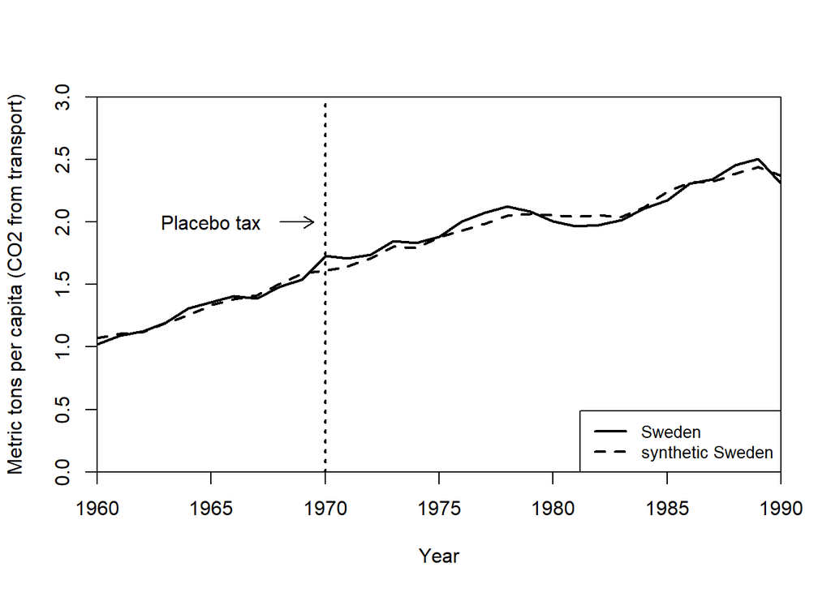

```r
 path.plot(synth.res = synth.out,
           dataprep.res = dataprep.out,
           Ylab = "Metric tons per capita (CO2 from transport)",
           Xlab = "Year",
           Ylim = c(0,3),
           Legend = c("Sweden","synthetic Sweden"),
           Legend.position = "bottomright"
           )

# Add line
abline(v=1970,lty="dotted",lwd=2)
arrows(1968,2.0,1969.5,2.0,col="black",length=.1)
Cex.set <- 1
text(1965,2.0,"Placebo tax",cex=Cex.set)
```

## Check placebo countries and calculate MSPE

Placebos using SCtools package:

```r
###################################################
### Figure 7:  Placebo in-space tests
###################################################

# Restore original data prep object (so treat year is 1990, not 1970 as above)
# and original synth results (should have just named them differently above)
dataprep.out <-
  dataprep(foo = carbontax,
           predictors = c("GDP_per_capita" , "gas_cons_capita" , "vehicles_capita" ,
                          "urban_pop") ,
           predictors.op = "mean" ,
           time.predictors.prior = 1980:1989 ,
           special.predictors = list(
             list("CO2_transport_capita" , 1989 , "mean"),
             list("CO2_transport_capita" , 1980 , "mean"),
             list("CO2_transport_capita" , 1970 , "mean")
           ),
           dependent = "CO2_transport_capita",
           unit.variable = "Countryno",
           unit.names.variable = "country",
           time.variable = "year",
           treatment.identifier = 13,
           controls.identifier = c(1:12, 14:15),
           time.optimize.ssr = 1960:1989,
           time.plot = 1960:2005
  )

 synth.out <- synth(data.prep.obj = dataprep.out,
                    method = "All")
```

```
##
## X1, X0, Z1, Z0 all come directly from dataprep object.
##
##
## ****************
##  searching for synthetic control unit
##
##
## ****************
## ****************
## ****************
##
## MSPE (LOSS V): 0.001222443
##
## solution.v:
##  0.2188493 0.009719276 0.07826532 0.2126716 0.1832151 0.2838626 0.01341685
##
## solution.w:
##  0.0007695733 0.1954709 5.61912e-05 0.3842992 0.0003365576 0.09042864 0.001226448 0.0003818197 0.1765464 0.0006891624 0.0003987502 0.0004105377 0.06109071 0.08789508
```

```r
# Using devtools and SCtools:
placebos <- generate.placebos(dataprep.out, synth.out)
```

```
##
## X1, X0, Z1, Z0 all come directly from dataprep object.
##
##
## ****************
##  searching for synthetic control unit
##
##
## ****************
## ****************
## ****************
##
## MSPE (LOSS V): 0.02038246
##
## solution.v:
##  0.001653575 0.1295889 0.03102601 0.2473949 0.1276963 0.001879037 0.4607613
##
## solution.w:
##  0.1745168 0.1316168 0.0001260608 0.0001344829 0.0001399556 0.4285009 0.0001179548 0.0004644841 7.98975e-05 8.09466e-05 0.0001323964 0.0001236841 0.2639657
##
##
## X1, X0, Z1, Z0 all come directly from dataprep object.
##
##
## ****************
##  searching for synthetic control unit
##
##
## ****************
## ****************
## ****************
##
## MSPE (LOSS V): 0.007539386
##
## solution.v:
##  0.1530809 0.1863672 0.1441098 0 0.1627062 0.160886 0.1928499
##
## solution.w:
##  0.0006406775 0.0003119821 0.401019 0.2011703 8.464e-07 0.1411278 0.002041207 0.006613267 0.000142357 0.0002691652 0.2461171 5.40957e-05 0.0004921847
##
```

[output cut: 224 more lines]

```
## ****************
##  searching for synthetic control unit
##
##
## ****************
## ****************
## ****************
##
## MSPE (LOSS V): 1.085804
##
## solution.v:
##  0.01160548 0.1064969 0.008817743 0.01620326 0.296976 0.0988363 0.4610643
##
## solution.w:
##  7.3e-09 2.3e-09 1 2.8e-09 2.2e-09 1.5e-09 2.9e-09 1.9e-09 3.7e-09 1.5e-09 1.3e-09 1.6e-09 2.8e-09
```

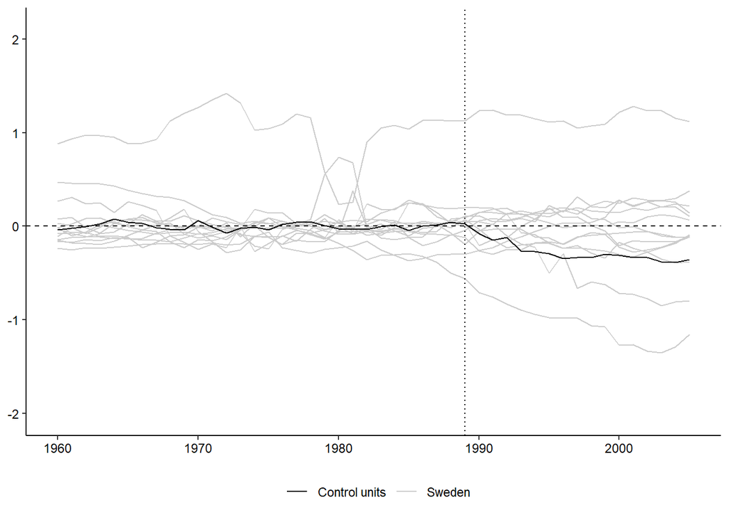

```r
plot_placebos(placebos)
```

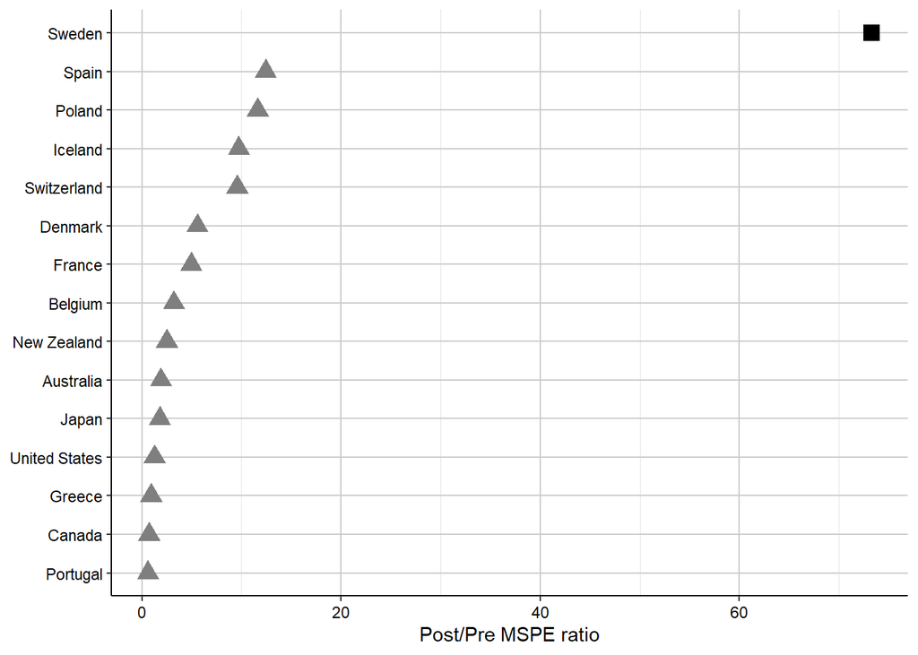

```r
mspe.plot(placebos)
```

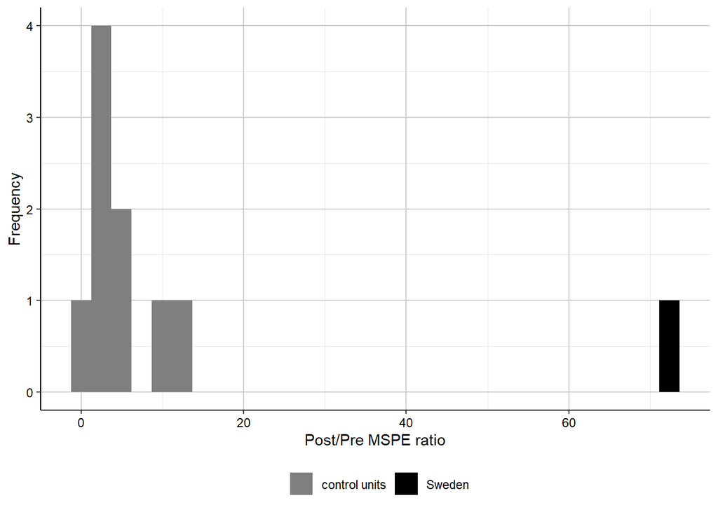

```r
mspe.plot(placebos, discard.extreme = TRUE, mspe.limit = 20, plot.hist = TRUE)
```

Calculating placebo effects “by hand”:

```r
# Running placebos "by hand"
store <- matrix(NA,length(1960:2005),15)
colnames(store) <- unique(carbontax$country)

# run placebo test
for(iter in 1:15)
 {
 dataprep.out <-
              dataprep(foo = carbontax,
                       predictors = c("GDP_per_capita" , "gas_cons_capita" , "vehicles_capita" ,
                                      "urban_pop") ,
                       predictors.op = "mean" ,
                       time.predictors.prior = 1980:1989 ,
                       special.predictors = list(
                         list("CO2_transport_capita" , 1989 , "mean"),
                list("CO2_transport_capita" , 1980 , "mean") ,
                list("CO2_transport_capita" , 1970 , "mean")
                      ),
                       dependent = "CO2_transport_capita",
                       unit.variable = "Countryno",
                       unit.names.variable = "country",
                       time.variable = "year",
                       treatment.identifier = iter,
                       controls.identifier = c(1:15)[-iter],
                       time.optimize.ssr = 1960:1989,
                       time.plot = 1960:2005
                       )



# run synth
synth.out <- synth(
                   data.prep.obj = dataprep.out,
                   method = "BFGS"
                   )

# store gaps
store[,iter] <- dataprep.out$Y1plot - (dataprep.out$Y0plot %*% synth.out$solution.w)
}
```

```
##
## X1, X0, Z1, Z0 all come directly from dataprep object.
##
##
## ****************
##  searching for synthetic control unit
##
##
## ****************
## ****************
## ****************
##
## MSPE (LOSS V): 0.02050707
##
## solution.v:
##  9.3128e-06 0.0923376 0.1222009 0.1665115 0.08936357 0.001468168 0.528109
##
## solution.w:
##  0.1620515 0.1736771 3.567e-07 1.705e-07 2.234e-07 0.4338658 1.858e-07 3.036e-07 1.522e-07 1.16e-07 2.091e-07 5.334e-07 1.504e-07 0.2304032
##
##
## X1, X0, Z1, Z0 all come directly from dataprep object.
##
##
## ****************
##  searching for synthetic control unit
##
##
## ****************
## ****************
## ****************
##
## MSPE (LOSS V): 0.004687469
##
## solution.v:
##  0.1786289 0.2452266 0.1751274 2.6747e-06 0.05897566 0.1804502 0.1615886
##
## solution.w:
##  0.0008232382 0.0007222787 0.4163812 0.2735356 2.2884e-06 0.07497473 0.04407866 4.9257e-06 0.0003196672 0.0004211639 0.1875344 0.0006955736 4.95e-08 0.0005062649
##
```

[output cut: 244 more lines]

```
## ****************
##  searching for synthetic control unit
##
##
## ****************
## ****************
## ****************
##
## MSPE (LOSS V): 1.085804
##
## solution.v:
##  0.01865466 0.0863511 0.01732622 0.005106409 0.286594 0.1123574 0.4736102
##
## solution.w:
##  7.1e-09 2.1e-09 1 2.5e-09 1.9e-09 1.2e-09 2.6e-09 1.6e-09 3.4e-09 1.2e-09 1.1e-09 1.4e-09 3.2e-09 2.5e-09
```

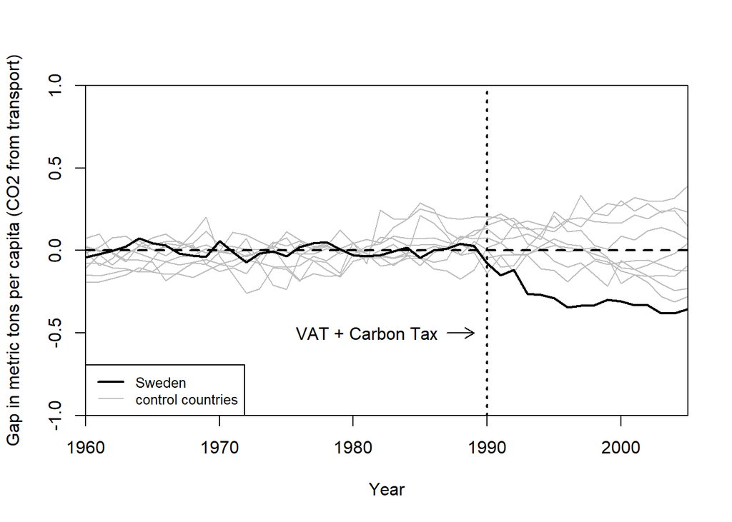

```r
# now do figure
data <- store
rownames(data) <- 1960:2005

# Set bounds in gaps data
gap.start     <- 1
gap.end       <- nrow(data)
years         <- 1960:2005
gap.end.pre  <- which(rownames(data)=="1989")

#  MSPE Pre-Treatment
mse        <- apply(data[ gap.start:gap.end.pre,]^2,2,mean)
sweden.mse <- as.numeric(mse[13])
# Exclude states with 20 times higher MSPE than Sweden (to include all countries, set value to 1000)
data <- data[,mse<20*sweden.mse]
Cex.set <- 1

# Plot
plot(years,data[gap.start:gap.end,which(colnames(data)=="Sweden")],
     ylim=c(-1,1),xlab="Year",
     xlim=c(1960,2005),ylab="Gap in metric tons per capita (CO2 from transport)",
     type="l",lwd=2,col="black",
     xaxs="i",yaxs="i")

# Add lines for control states
for (i in 1:ncol(data)) { lines(years,data[gap.start:gap.end,i],col="gray") }

## Add Sweden Line
lines(years,data[gap.start:gap.end,which(colnames(data)=="Sweden")],lwd=2,col="black")

# Add grid
abline(v=1990,lty="dotted",lwd=2)
abline(h=0,lty="dashed",lwd=2)
legend("bottomleft",legend=c("Sweden","control countries"),
lty=c(1,1),col=c("black","gray"),lwd=c(2,1),cex=.8)
arrows(1987,-0.5,1989,-0.5,col="black",length=.1)
text(1981,-0.5,"VAT + Carbon Tax",cex=Cex.set)
abline(v=1960)
abline(v=2005)
abline(h=-1)
abline(h=1)
```

```r
###################################################
### Figure 8: Ratio Test: Ratios of Post-Treatment MSPE to Pre-Treatment MSPE
###################################################
# Figure 8 was made using Microsoft Excel. Below is an example on how the data for this figure was created
# Example: Postperiod MSPE / Preperiod MSPE for Sweden (treatment.identifier = 13)

 dataprep.out <-
              dataprep(foo = carbontax,
                       predictors = c("GDP_per_capita" , "gas_cons_capita" , "vehicles_capita" ,
                                      "urban_pop") ,
                       predictors.op = "mean" ,
                       time.predictors.prior = 1980:1989 ,
                       special.predictors = list(
                         list("CO2_transport_capita" , 1989 , "mean"),
                         list("CO2_transport_capita" , 1980 , "mean"),
                         list("CO2_transport_capita" , 1970 , "mean")
                                                ),
                       dependent = "CO2_transport_capita",
                       unit.variable = "Countryno",
                       unit.names.variable = "country",
                       time.variable = "year",
                       treatment.identifier = 13,
                       controls.identifier = c(1:12, 14:15),
                       time.optimize.ssr = 1960:1989,
                       time.plot = 1960:2005
                       )

 synth.out <- synth(data.prep.obj = dataprep.out,
                    method = "All")
```

```
##
## X1, X0, Z1, Z0 all come directly from dataprep object.
##
##
## ****************
##  searching for synthetic control unit
##
##
## ****************
## ****************
## ****************
##
## MSPE (LOSS V): 0.001222443
##
## solution.v:
##  0.2188493 0.009719276 0.07826532 0.2126716 0.1832151 0.2838626 0.01341685
##
## solution.w:
##  0.0007695733 0.1954709 5.61912e-05 0.3842992 0.0003365576 0.09042864 0.001226448 0.0003818197 0.1765464 0.0006891624 0.0003987502 0.0004105377 0.06109071 0.08789508
```

```r
 gaps <- dataprep.out$Y1plot - (dataprep.out$Y0plot %*% synth.out$solution.w)
 mspepost <- mean((gaps[31:46, 1])^2)
 mspepre <- mean((gaps[1:30, 1])^2)
 mspepost/mspepre
```

```
## [1] 73.272
```

## Conduct the leave-one-out test

```r
###################################################
### Figure 9: Leave-One-Out: Distribution of the Synthetic Control for Sweden
###################################################
# Iteratively eliminate one of the six control countries that got a W weight larger than 0.001
# Example: eliminating New Zealand

 dataprep.out <-
              dataprep(foo = carbontax,
                       predictors = c("GDP_per_capita" , "gas_cons_capita" , "vehicles_capita" ,
                                      "urban_pop") ,
                       predictors.op = "mean" ,
                       time.predictors.prior = 1980:1989 ,
                       special.predictors = list(
                         list("CO2_transport_capita" , 1989 , "mean"),
                         list("CO2_transport_capita" , 1980 , "mean"),
                         list("CO2_transport_capita" , 1970 , "mean")
                                                ),
                       dependent = "CO2_transport_capita",
                       unit.variable = "Countryno",
                       unit.names.variable = "country",
                       time.variable = "year",
                       treatment.identifier = 13,
                       controls.identifier = c(1:8, 10:12, 14:15),
                       time.optimize.ssr = 1960:1989,
                       time.plot = 1960:2005
                       )

synth.out <- synth(data.prep.obj = dataprep.out,
                    method = "All")
```

```
##
## X1, X0, Z1, Z0 all come directly from dataprep object.
##
##
## ****************
##  searching for synthetic control unit
##
##
## ****************
## ****************
## ****************
##
## MSPE (LOSS V): 0.001479115
##
## solution.v:
##  0.005582893 0.009475485 0.003215815 0.3597227 0.1239453 0.4052939 0.09276386
##
## solution.w:
##  0.002068293 0.3138772 0.0003571681 0.373265 0.004572283 0.05694911 0.001172922 0.004518083 0.01316495 0.01622783 0.01013312 0.08759249 0.1161016
```

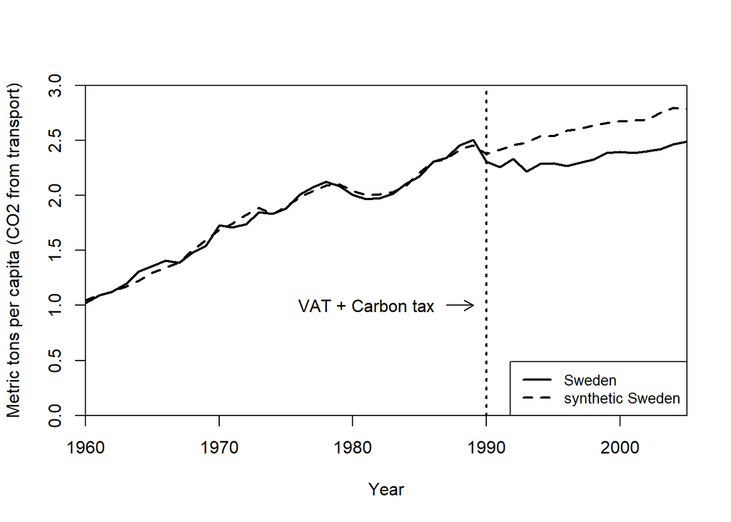

```r
  path.plot(synth.res = synth.out,
           dataprep.res = dataprep.out,
           Ylab = "Metric tons per capita (CO2 from transport)",
           Xlab = "Year",
           Ylim = c(0,3),
           Legend = c("Sweden","synthetic Sweden"),
           Legend.position = "bottomright"
           )
# Add line
abline(v=1990,lty="dotted",lwd=2)
arrows(1987,1.0,1989,1.0,col="black",length=.1)
Cex.set <- 1
text(1981,1.0,"VAT + Carbon tax",cex=Cex.set)
```

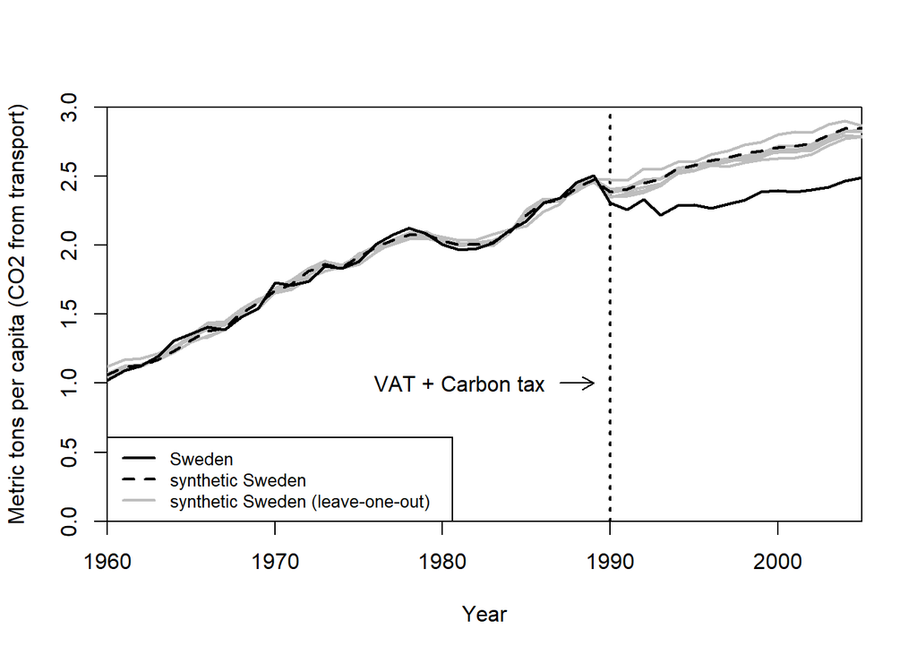

```r
# To create Figure 9, load file: leave_one_out_data.dta
setwd("C:/Users/gilbe/Dropbox/Econometrics/Petes Class/EB 590 Spring 2021/CarbonTaxSynthExample")
leaveoneout <- read_dta("leave_one_out_data.dta") %>%
  as.data.frame(.)
attach(leaveoneout)

plot(Year[1:46], sweden, type="l", lwd=2, col="black", ylim=c(0,3.0), xlab="Year", ylab="Metric tons per capita (CO2 from transport)", xaxs="i",yaxs="i" )
abline(v=1990,lty="dotted",lwd=2)
legend("bottomleft",legend=c("Sweden","synthetic Sweden", "synthetic Sweden (leave-one-out)   "),
lty=c(1,2,1),col=c("black","black","gray"),lwd=c(2,2,2),cex=0.8)
lines(Year, excl_belgium, lty="solid" ,lwd=2, col="gray")
lines(Year, excl_denmark, lty="solid",lwd=2, col="gray")
lines(Year, excl_greece, lty="solid" ,lwd=2, col="gray")
lines(Year, excl_newzealand, lty="solid" ,lwd=2, col="gray")
lines(Year, excl_switzerland, lty="solid" ,lwd=2, col="gray")
lines(Year, excl_unitedstates, lty="solid" ,lwd=2, col="gray")
lines(Year, synth_sweden, lty="dashed" , lwd=2, col="black")
lines(Year, sweden, lty="solid" , lwd=2, col="black")
arrows(1987,1.0,1989,1.0,col="black",length=.1)
Cex.set <- 1
text(1981,1.0,"VAT + Carbon tax",cex=Cex.set)
```

## Compare full sample of donor pool to trimmed sample

```r
###################################################
### Figure 10: Path and Gap plot of per capita CO2 Emissions from Transport: Main Results vs. Full Sample
###################################################
# Load file: carbontax_fullsample_data.dta

setwd("C:/Users/gilbe/Dropbox/Econometrics/Petes Class/EB 590 Spring 2021/CarbonTaxSynthExample")
carbontax_fullsample <- read_dta("carbontax_fullsample_data.dta") %>%
  as.data.frame(.)
attach(carbontax_fullsample)

 dataprep.out <-
              dataprep(foo = carbontax_fullsample,
                       predictors = c("GDP_per_capita" , "gas_cons_capita" , "vehicles_capita" ,
                                      "urban_pop") ,
                       predictors.op = "mean" ,
                       time.predictors.prior = 1980:1989 ,
                       special.predictors = list(
                         list("CO2_transport_capita" , 1989 , "mean"),
                         list("CO2_transport_capita" , 1980 , "mean"),
                         list("CO2_transport_capita" , 1970 , "mean")
                                                ),
                       dependent = "CO2_transport_capita",
                       unit.variable = "Countryno",
                       unit.names.variable = "country",
                       time.variable = "year",
                       treatment.identifier = 21,
                       controls.identifier = c(1:20, 22:25),
                       time.optimize.ssr = 1960:1989,
                       time.plot = 1960:2005
                       )


synth.out <- synth(data.prep.obj = dataprep.out,
                    method = "All")
```

```
##
## X1, X0, Z1, Z0 all come directly from dataprep object.
##
##
## ****************
##  searching for synthetic control unit
##
##
## ****************
## ****************
## ****************
##
## MSPE (LOSS V): 0.001307056
##
## solution.v:
##  0.1236562 0.002837484 0.2445794 0.1842555 0.1715674 0.2491933 0.02391063
##
## solution.w:
##  0.001430314 0.002187511 0.09669058 0.0005494912 0.4788219 0.003796042 0.002192524 0.002489731 0.002762957 0.001300127 0.00181119 0.001815266 0.002254425 0.01153836 0.001817766 0.172445 0.001938909 0.002589772 0.001991325 0.002277864 0.01181584 0.002537032 0.1282806 0.06466547
```

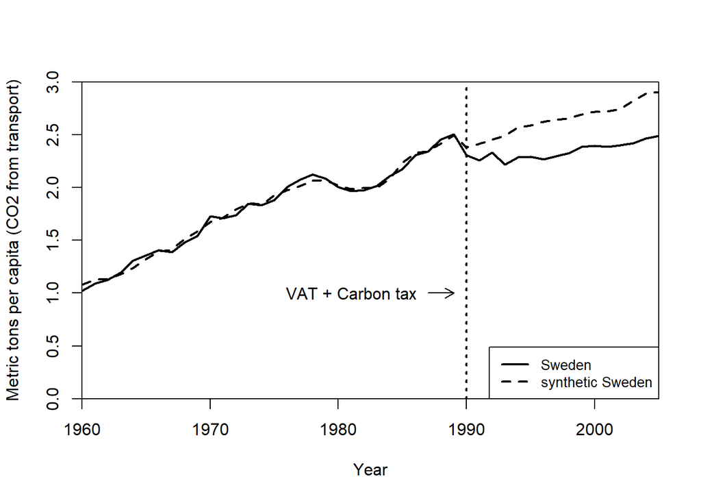

```r
  path.plot(synth.res = synth.out,
           dataprep.res = dataprep.out,
           Ylab = "Metric tons per capita (CO2 from transport)",
           Xlab = "Year",
           Ylim = c(0,3),
           Legend = c("Sweden","synthetic Sweden"),
           Legend.position = "bottomright"
           )
# Add line
abline(v=1990,lty="dotted",lwd=2)
arrows(1987,1.0,1989,1.0,col="black",length=.1)
Cex.set <- 1
text(1981,1.0,"VAT + Carbon tax",cex=Cex.set)
```

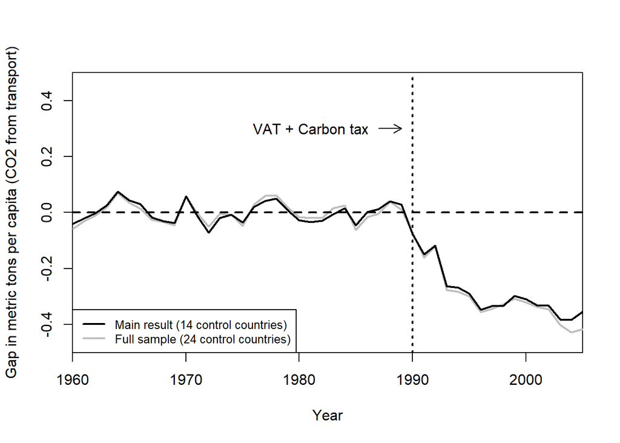

```r
# To create Figure 10, load file: fullsample_figures.dta
fullsample_figures <- read_dta("fullsample_figures.dta")
attach(fullsample_figures)
# Gap plot
plot(Year, CO2_reductions_full_sample, type="l", lwd=2, col="gray", ylim=c(-0.50,0.50), xlab="Year" , ylab="Gap in metric tons per capita (CO2 from transport)", xaxs="i",yaxs="i")
lines(Year, CO2_reductions_full_sample, lty="solid", lwd=2, col="gray")
abline(v=1990,lty="dotted",lwd=2)
abline(h = 0, col = "black", lty = "dashed", lwd = 2)
legend("bottomleft",legend=c("Main result (14 control countries)" ,"Full sample (24 control countries)"),
lty=c(1,1),col=c("black","gray"),lwd=c(2,2),cex=0.8)
lines(Year, CO2_reductions_original_sample, lty="solid", lwd=2, col="black")
arrows(1987,0.3,1989,0.3,col="black",length=.1)
Cex.set <- 1
text(1981,0.3,"VAT + Carbon tax",cex=Cex.set)
```

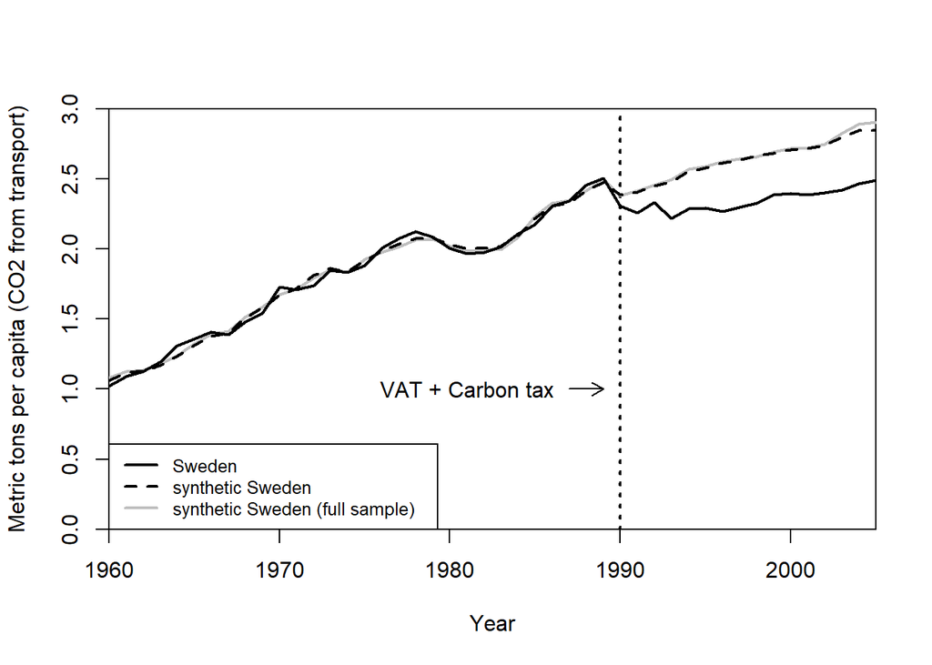

```r
# Path plot
plot(Year[1:46], sweden, type="l", lwd=2, col="black", ylim=c(0,3.0), xlab="Year", ylab="Metric tons per capita (CO2 from transport)", xaxs="i",yaxs="i" )
abline(v=1990,lty="dotted",lwd=2)
legend("bottomleft",legend=c("Sweden","synthetic Sweden", "synthetic Sweden (full sample)   "),
lty=c(1,2,1),col=c("black","black","gray"),lwd=c(2,2,2),cex=0.8)
lines(Year, synth_sweden_full_sample, lty="solid" ,lwd=2, col="gray")
lines(Year, synth_sweden_original_sample, lty="dashed" , lwd=2, col="black")
lines(Year, sweden, lty="solid" , lwd=2, col="black")
arrows(1987,1.0,1989,1.0,col="black",length=.1)
Cex.set <- 1
text(1981,1.0,"VAT + Carbon tax",cex=Cex.set)
```

# Compare to SCUL method and package

This is not an apples to apples comparison - SCUL does not apply the LASSO penalty to the Synth objective function. It uses the full pre-treatment time series of donor outcomes and predictors (instead of potential summary statistics and other linear combinations of those predictors, as in Synth).

Possible predictors: donor units’ time series of GDP per capita, gas consumption per capita, vehicles per capita, urban population, as well as donor units’ pretreatment outcome of CO2 emissions from transport.

Prepare data:

```r
# remove redundant country index and unused predictors
datasetup <- carbontax %>% select(-c("country","pop_density"))
# column order by country
datasetup <- pivot_wider(datasetup, names_vary="slowest", names_from = "Countryno", values_from = c("CO2_transport_capita", "GDP_per_capita" , "gas_cons_capita" , "vehicles_capita" , "urban_pop"))

# for full donor pool use all time series from all donor countries (not Sweden country 13)
XData <- datasetup %>% select(-c("year", "CO2_transport_capita_13", "GDP_per_capita_13", "gas_cons_capita_13", "vehicles_capita_13", "urban_pop_13"))

# for limited donor pool, just use pre-treatment donor outcomes
Ydonors <- unlist(dataprep.out$Y0plot)
Ydonors <- as.data.frame(unlist(Ydonors))

# outcome series
YData <- unlist(dataprep.out$Y1plot)
YData <- as.data.frame(unlist(YData))
#YData <- datasetup %>% select(c("year", "CO2_transport_capita_13"))
#colnames(YData) <- c("year", "CO2_transport_capita")
# time index
year <- carbontax %>% select("year") %>% distinct(year)
YData <- cbind(year, YData)
colnames(YData) <- c("year", "CO2_transport_capita")
```

Process data for use by SCUL package. Here I’m using all the possible donor time series, but could replace “XData” with “Ydonors” if only wanted pre-treatment outcomes from the donor pool:

```r
# Preprocess() checks for non-numeric, missing, or constant variables
# drops any column that has any of these issues
processed.YData <- Preprocess(YData)

# cross validation will be run on many subsets. Need to make sure each subset
# also has variation using PreprocessSubset().
# Identical to Preprocess() but runs on each CV subset
TreatmentBeginsAt <- 31 # Here the 31st row is 1990
PostPeriodLength <- nrow(processed.YData) - TreatmentBeginsAt + 1
PrePeriodLength <- TreatmentBeginsAt-1
# Ideally equal to post-treatment, but shorter if not many pre-treatment time periods
#NumberInitialTimePeriods <- 10
NumberInitialTimePeriods <- 5
processed.YData <- PreprocessSubset(processed.YData,
                                       TreatmentBeginsAt ,
                                       NumberInitialTimePeriods,
                                       PostPeriodLength,
                                       PrePeriodLength)
head(processed.YData)
```

```
##      year CO2_transport_capita
## 1960 1960             1.020755
## 1961 1961             1.093085
## 1962 1962             1.125425
## 1963 1963             1.196687
## 1964 1964             1.310473
## 1965 1965             1.358960
```

```r
# create list (SCUL.input) for later SCUL commands to call
# applies PreprocessSubset() and Preprocess() to all data
# want all entries (time, y, x.DonorPool, x.PlaceboPool) to be data.frames
# Cohen's D is a unit-free measure of fit between Y.actual and Y.scul
# It's the standardized mean difference between Y.actual and Y.scul in pretreatment period
# measured in standard deviation terms. Max of 0.25 std. devs is a rule of thumb.
SCUL.input <- OrganizeDataAndSetup (
  time =  YData %>% select(year),
  y = YData %>% select(CO2_transport_capita),
  TreatmentBeginsAt = TreatmentBeginsAt,
  x.DonorPool = XData,
  CohensDThreshold = 0.25,
  NumberInitialTimePeriods = NumberInitialTimePeriods,
  TrainingPostPeriodLength = 7,
  x.PlaceboPool = XData,
  OutputFilePath="C:/Users/gilbe/Dropbox/"
)
```

Fit the model and plot some diagnostics:

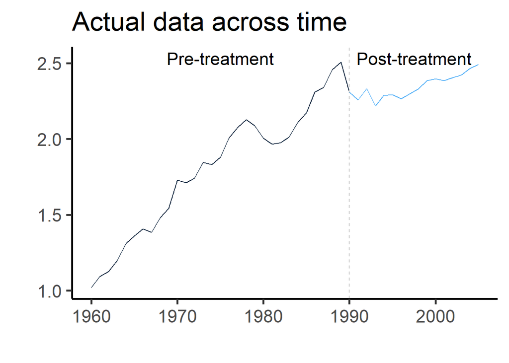

```r
# Estimation by LASSO with rolling CV
SCUL.output <- SCUL(plotCV == TRUE)
GraphTargetData()
```

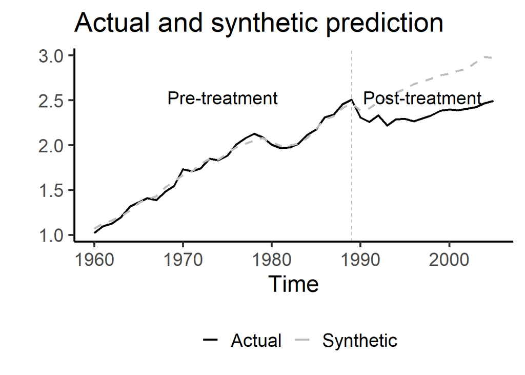

```r
PlotActualvSCUL()
```

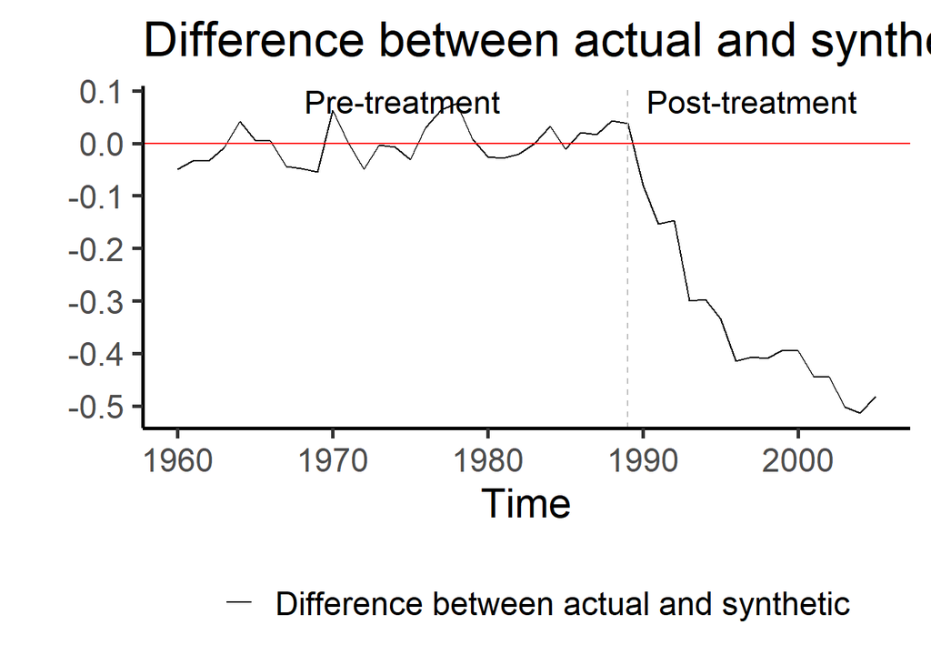

```r
PlotDiffOfActualvSCUL()
```

```r
PlotShareTable()
```

|  | Share for First Prediction | Share for Most Recent Prediction | Coefficient |
| --- | --- | --- | --- |
| CO2_transport_capita_2 | 0.26 | 0.25 | 0.31 |
| CO2_transport_capita_4 | 0.23 | 0.23 | 0.28 |
| vehicles_capita_4 | 0.14 | 0.15 | 0.00 |
| CO2_transport_capita_9 | 0.14 | 0.14 | 0.13 |
| CO2_transport_capita_15 | 0.08 | 0.07 | 0.03 |
| GDP_per_capita_9 | 0.08 | 0.09 | 0.00 |
| Intercept | 0.03 | 0.02 | 0.07 |
| CO2_transport_capita_12 | 0.03 | 0.03 | 0.04 |
| GDP_per_capita_12 | 0.01 | 0.02 | 0.00 |
| gas_cons_capita_4 | 0.00 | 0.00 | 0.00 |

Now do some inference on how well the model performs:

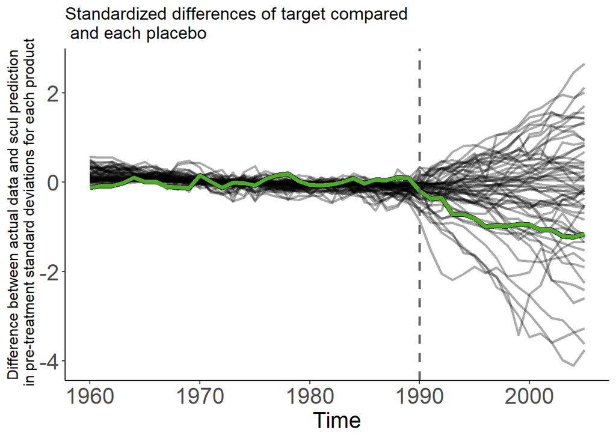

```r
# Really should restrict each placebo not to have it's (endogenous) variables in the donor pool
drop_vars_from_same_FIPS <-
  "select(-ends_with(substring(names(x.PlaceboPool)[h],nchar(names(x.PlaceboPool)[h]) - 2 + 1, nchar(names(x.PlaceboPool)[h]))))"

SCUL.inference <- CreatePlaceboDistribution(
  DonorPoolRestrictionForEachPlacebo = drop_vars_from_same_FIPS
)

smoke_plot <- SmokePlot()
smoke_plot
```

Compare null distribution of placebo effects to actual effect:

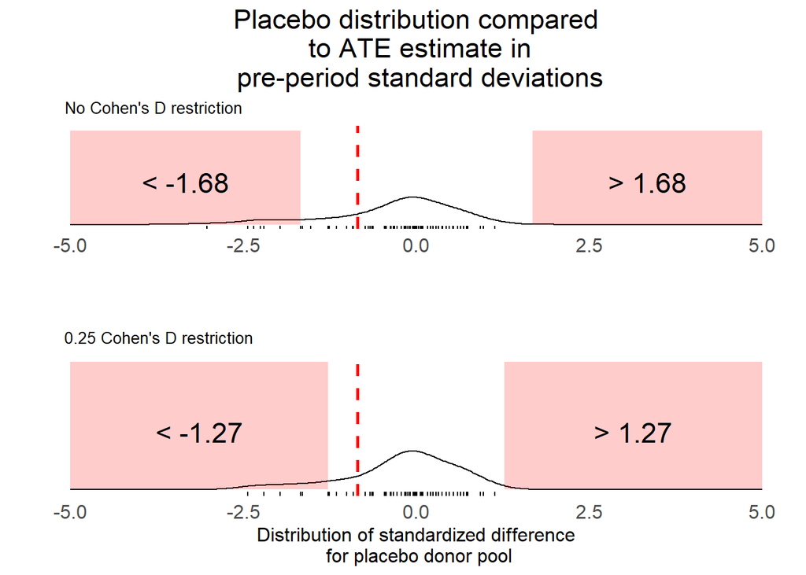

```r
# Grab standardized differences from saved objects
Results.y.StandardizedDiff <- unlist(smoke_plot$layers[[2]]$data$std_diff)
Results.y.StandardizedDiff <- as.data.frame(unlist(Results.y.StandardizedDiff))

# Show distribution of standardized differences (treatment effects) in placebo pool
# vs estimated difference
# with and without a Cohen's D restriction on pre-period fit in placebo pool
# Rejection region is 10% of distribution
# narrower null distribution around zero is better

# Plot null distribution with no restriction on pre-period fit
NullDist.Full <- PlotNullDistribution(
  CohensD = 999,
  StartTime = TreatmentBeginsAt,
  EndTime = length(SCUL.output$y.actual),
  height = 2,
  AdjustmentParm = 1,
  BandwidthParm = .25,
  title_label = "Placebo distribution compared\n to ATE estimate in\n pre-period standard deviations",
  y_label  = " ",
  x_label  =  "",
  subtitle_label  =  "No Cohen's D restriction",
  rejection_label  =  ""
) +
  geom_vline(
    xintercept = mean(Results.y.StandardizedDiff[TreatmentBeginsAt:nrow(Results.y.StandardizedDiff),]),
    linetype = "dashed",
    size = 1,
    color = "red")
# Plot null distribution 0.25 cohen's D restriction on pre-period fit
NullDist.25 <- PlotNullDistribution(
  CohensD = 0.25,
  StartTime = TreatmentBeginsAt,
  EndTime = length(SCUL.output$y.actual),
  height = 2,
  AdjustmentParm = 1,
  BandwidthParm = .25,
  y_label  = "",
  x_label  =  "Distribution of standardized difference\n for placebo donor pool",
  subtitle_label  =  "0.25 Cohen's D restriction",
  rejection_label  =  "",
  title_label = " ",

) +
  geom_vline(
    xintercept = mean(Results.y.StandardizedDiff[TreatmentBeginsAt:nrow(Results.y.StandardizedDiff),]),
    linetype = "dashed",
    size = 1,
    color = "red")

# Plot n
# Combine the three plots
combined_plot <- plot_grid(
  NullDist.Full,NullDist.25,
  ncol = 1)

# Display the plot
combined_plot
```

Calculate p-values for treatment significance:

```r
# Permutation-based p-values of treatment significance:
PValue(
  CohensD = 999,
  StartTime = SCUL.input$TreatmentBeginsAt,
  EndTime = nrow(Results.y.StandardizedDiff)
)
```

```
##   p.value.high
## 1         0.26
```

```r
PValue(
  CohensD = .25,
  StartTime = SCUL.input$TreatmentBeginsAt,
  EndTime = nrow(Results.y.StandardizedDiff)
)
```

```
##   p.value.high
## 1         0.23
```